# Gene expression - nascent transcripts

Tom van Schaik

2022-01-21

### Introduction

Question: how does differential localization matches with gene expression?

That is, for the different AID depletions. Is there any link between the two?

### Method

I will use the processed counts from NQ and perform simple differential analyses.

This time, for TTseq data.

This document will perform the differential analysis. I will compare these with DamID values later.

### Set-up

Set the parameters and list the data.

```r
# Load dependencies
library(tidyverse)
library(GenomicRanges)
library(rtracklayer)
library(ggplot2)
library(ggbeeswarm)
library(DESeq2)
library(RColorBrewer)
library(pheatmap)
library(GGally)

# Prepare output
output_dir <- "ts220117_NascentExpression"
dir.create(output_dir, showWarnings = FALSE)
```

```r
library(knitr)
opts_chunk$set(fig.width = 10, fig.height = 4, dev=c('png', 'pdf'),
               fig.path = file.path(output_dir, "figures/"))
pdf.options(useDingbats = FALSE)
```

```r
DifferentialAnalysis <- function(dds, contrast, exp, control, genes_results,
                                 lfcThreshold = 0.5, alpha = 0.05) {

  main = paste(exp, "vs", control, sep = "_")

  # Run DESeq2 results
  res <- results(dds, lfcThreshold = lfcThreshold,
                 contrast = c(contrast, exp, control))

  # Prepare MAplot
  tib <- as_tibble(res) %>%
    drop_na() %>%
    mutate(shape = case_when(log2FoldChange > 8 ~ 2,
                             log2FoldChange < -8 ~ 2,
                             T ~ 1),
           log2FoldChange = case_when(log2FoldChange > 8 ~ 8,
                                      log2FoldChange < -8 ~ -8,
                                      T ~ log2FoldChange))

  # Prepare plot
  plt <- tib %>%
      ggplot(aes(x = baseMean, y = log2FoldChange)) +
      geom_bin2d(data = tib[tib$padj >= 0.05, ], bins = 100) +
      xlab("Mean expression (cpm)") +
      ylab("Expression difference (log2)") +
      ggtitle(main) +
      ylim(-8, 8) +
      scale_x_log10() +
      scale_color_manual(values = c("red"), name = "Significant") +
      scale_shape_discrete(guide = FALSE) +
      scale_fill_gradient(low = "lightgrey", high = "black", name = "Count") +
      theme_bw() +
      theme(aspect.ratio = 1)

  if (any(tib$padj < 0.05)) {
    plt <- plt +
      geom_point(data = tib[tib$padj < 0.05, ], aes(col = T,
                                                    shape = factor(shape)),
                 size = 1, show.legend = T)
  }
  plot(plt)

  # Add results to genes_results
  mcols(genes_results)[, paste0(main, c("_baseMean", "_log2FoldChange", "_padj"))] <-
    res[, c("baseMean", "log2FoldChange", "padj")]

  # Add differential results
  mcols(genes_results)[, paste0(main, "_sign")] <- "stable"
  mcols(genes_results)[which(res$log2FoldChange > 0 & res$padj < 0.05),
                       paste0(main, "_sign")] <- "up"
  mcols(genes_results)[which(res$log2FoldChange < 0 & res$padj < 0.05),
                       paste0(main, "_sign")] <- "down"

  genes_results
}
```

### 1) Load data

Load data from NQ

```r
# Load genes from NQ - filter for gene entries
genes <- import("Data_NQ/RNAseq/Mus_musculus.GRCm38.92_withChr.gtf")
genes <- genes[genes$type == "gene"]


# Load counts from NQ
#tib_wapl_cw <- read_tsv("Data_NQ/RNAseq/Wapl_CtcfWapl_RNA_htseqcounts_unnormalized.txt")
#tib_rad <- read_tsv("Data_NQ/RNAseq/Rad21_RNA_htseqcounts_unnormalized.txt")
tib_counts <- read_tsv("Data_NQ/TTseq/NascentRNA_nostranded_htseqcounts_unnormalized.txt")


# Prepare metadata
metadata <- tibble(file_name = names(tib_counts)) %>%
  filter(file_name != "ensembl_id") %>%
  rowwise() %>%
  mutate(target = case_when(T ~ "WAPL"),
         replicate = case_when(grepl("rep2", file_name) ~ "r2",
                               grepl("rep3", file_name) ~ "r3",
                               T ~ "r1"),
         timepoint = case_when(grepl("24H", file_name) ~ "24h",
                               grepl("6H", file_name) ~ "6h",
                               T ~ "0h"),
         clone = case_when(grepl("C20", file_name) ~ "C20",
                           grepl("C6", file_name) ~ "C6",
                           T ~ "X")) %>%
  # Manual fix of sample mixing
  ungroup() %>%
  mutate(new_name = paste(target, timepoint, replicate,
                          sep = "_"),
         target_timepoint = factor(paste(target, timepoint,
                                         sep = "_"))) %>%
  mutate(target = factor(target,
                         levels = c("WT",
                                    "CTCFEL", "CTCFNQ",
                                    "WAPL", "CTCFWAPL",
                                    "RAD21")),
         timepoint = factor(timepoint,
                            levels = c("0h", "6h", "24h",
                                       "48h", "96h")),
         replicate = factor(replicate,
                            levels = c("r1", "r2", "r3")))


# Combine counts and rename
tib_counts <- tib_counts %>%
  rename_all(~ c("ensembl_id", metadata$new_name)) %>%
  filter(! str_detect(ensembl_id, "__")) %>%
  right_join(tibble(ensembl_id = genes$gene_id))

# Re-order counts
tib_counts <- tib_counts[match(genes$gene_id, tib_counts$ensembl_id), ]


# Only work with protein_coding genes and "normal" chromosomes
idx <- which(genes$gene_biotype %in% c("protein_coding") &
               seqnames(genes) %in% c(paste0("chr", 1:19), "chrX"))

genes <- genes[idx]
tib_counts <- tib_counts[idx, ]
```

### 2) Initialize DESeq2

Load counts into DESeq2.

```r
set.seed(1)

# Convert tibble to named data.frame
df_counts <- as.data.frame(tib_counts %>%
                             dplyr::select(-ensembl_id))
row.names(df_counts) <- tib_counts$ensembl_id

# Load this into DESeq2
dds <- DESeqDataSetFromMatrix(countData = df_counts,
                                     colData = data.frame(metadata),
                                     design= ~ target_timepoint)
dds <- DESeq(dds)
```

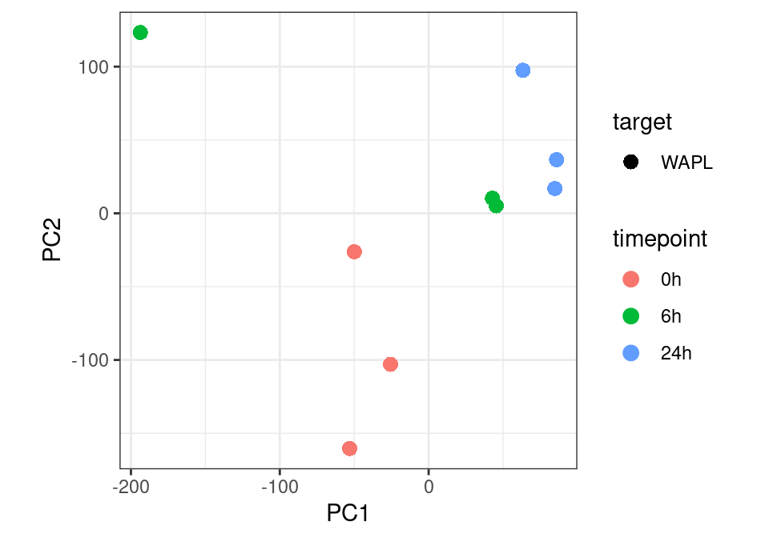

```r
# Get the "transformed" values and create PCA plot
dds_vsd <- vst(dds, blind = FALSE)
dds_vsd <- normTransform(dds, pc = 0.001)

pca_df <- plotPCA(dds_vsd, intgroup = c("target"), ntop = 5000,
                  returnData = T)

# Add metadata and plot
as_tibble(pca_df) %>%
  bind_cols(metadata %>%
              dplyr::select(-target)) %>%
  ggplot(aes(x = PC1, y = PC2, col = timepoint, shape = target)) +
    geom_point(size = 3) +
    theme_bw() +
    theme(aspect.ratio = 1)
```

Okay, now we have the RNAseq samples (gene counts) loaded the PCA plot confirms that the samples are not too bad.

### 3) FPKM values

I want FPKM values to use as measure of gene expression. Get these.

To do this, I need to determine “gene length” for all the genes. Of course, RNA-seq only captures exons, so I need to gather the length of only exons.

```r
# Call to determine gene length:
#python /home/t.v.schaik/mydata/proj/sManzo_pADamID/ts190515_pADamID_RPE_Top1_DRB/bin/gtftools.py -l Data_NQ/Mus_musculus.GRCm38.92_withChr_geneLength.bed Data_NQ/Mus_musculus.GRCm38.92_withChr.gtf

# Read gene lengths
tib_geneLength <- read_tsv("Data_NQ/RNAseq/Mus_musculus.GRCm38.92_withChr_geneLength.bed") %>%
  dplyr::rename(gene_id = "gene")
# Add to genes
tib_geneLength <- tibble(gene_id = genes$gene_id) %>%
  left_join(tib_geneLength)
```

```r
genes$length <- tib_geneLength$mean

# Add genelength
mcols(dds)$basepairs <- genes$length

# Get FPKM
tib_fpkm <- as_tibble(fpkm(dds)) %>%
  add_column(ensembl_id = tib_counts$ensembl_id)

# Get mean FPKM per sample
tmp <- do.call(cbind, tapply(metadata$new_name,
                             interaction(metadata$target,
                                         metadata$timepoint),
                             function(x) {
                               if (length(x) > 1) {
                                 rowMeans(tib_fpkm[, x])
                               } else {
                                 tib_fpkm[, x]
                               }}))

tib_fpkm_mean <- tib_fpkm %>%
  dplyr::select(ensembl_id) %>%
  bind_cols(as_tibble(tmp) %>%
              rename_all(function(x) gsub("\\.", "_", x)))


# Save as RDS
saveRDS(tib_fpkm,
        file.path(output_dir,
                  "genes_fpkm.rds"))
saveRDS(tib_fpkm_mean,
        file.path(output_dir,
                  "genes_fpkm_mean.rds"))
saveRDS(genes,
        file.path(output_dir,
                  "genes.rds"))


# Also, write bigwig files of the FPKM
bigwig_dir <- file.path(output_dir,
                        "bigwig")
dir.create(bigwig_dir, showWarnings = F)

genes_ranges <- genes
mcols(genes_ranges) <- NULL
start(genes_ranges) <- end(genes_ranges) <- ifelse(strand(genes_ranges) == "+",
                                                   start(genes_ranges),
                                                   end(genes_ranges))

# Add seqinfo
chrom_info <- read.table("~/mydata/data/genomes/mm10/mm10.chrom.sizes",
                         sep = "\t", stringsAsFactors = F)
row.names(chrom_info) <- chrom_info[, 1]
seqlengths(genes_ranges) <- chrom_info[seqlevels(genes_ranges), 2]

# Export bigwigs
for (n in names(tib_fpkm_mean)) {

  # Not for the gene ID of course
  if (n == "ensembl_id") next

  # Temporary ranges
  genes_tmp <- genes_ranges
  genes_tmp$score <- tib_fpkm_mean %>% pull(n)

  # Remove duplicates ranges
  genes_tmp <- genes_tmp[! duplicated(paste0(seqnames(genes_tmp),
                                             start(genes_tmp)))]

  # Remove NAs
  genes_tmp <- genes_tmp[! is.na(genes_tmp$score)]

  # Remove seqlevels without seqlenghts
  genes_tmp <- genes_tmp[seqnames(genes_tmp) %in% seqlevels(genes_tmp)[! is.na(seqlengths(genes_tmp))]]
  seqlevels(genes_tmp) <- as.character(unique(seqnames(genes_tmp)))

  # Export as bigwig
  export.bw(genes_tmp, file.path(bigwig_dir,
                                 paste0(n, ".bw")))
}
```

### 4) Differential analysis

I want gene lists to play with. Up and downregulated genes versus stable genes. Let’s do some simple one-to-one differential tests.

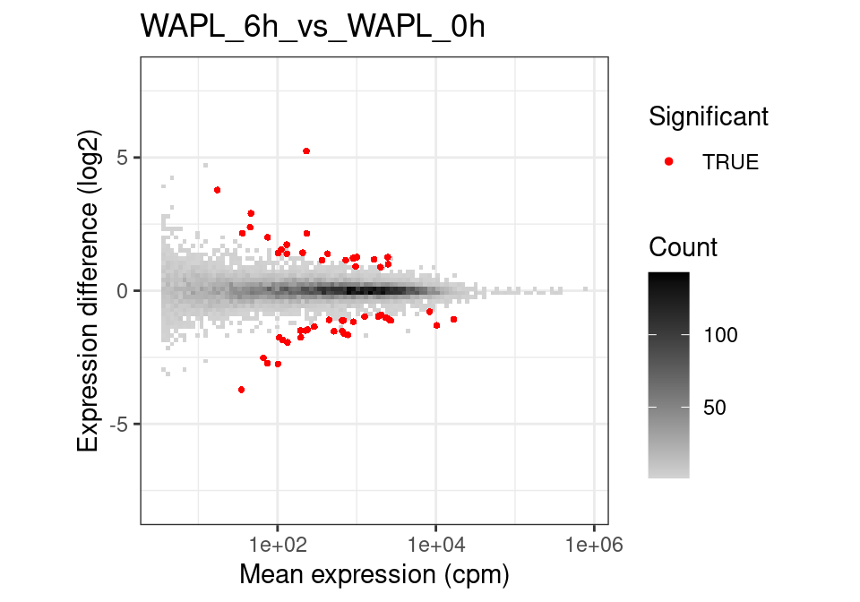

```r
# Prepare genes object with output of differential analyses
genes_results <- genes
mcols(genes_results) <- NULL

# Differential analysis - make MAplot and save results

# 4) WAPL timecourse
genes_results <- DifferentialAnalysis(dds, "target_timepoint",
                                      "WAPL_6h", "WAPL_0h",
                                      genes_results)
```

```r
genes_results <- DifferentialAnalysis(dds, "target_timepoint",
                                      "WAPL_24h", "WAPL_0h",
                                      genes_results)
```

[figure not shown]

```r
# Save as rds
saveRDS(genes_results,
        file.path(output_dir,
                  "genes_results.rds"))

# Show results
as_tibble(mcols(genes_results)) %>%
  dplyr::select(contains("sign")) %>%
  dplyr::summarise_all(function(x) sum(x == "up"))
```

```
## # A tibble: 1 × 2
##   WAPL_6h_vs_WAPL_0h_sign WAPL_24h_vs_WAPL_0h_sign
##                     <int>                    <int>
## 1                      23                      177
```

```r
as_tibble(mcols(genes_results)) %>%
  dplyr::select(contains("sign")) %>%
  dplyr::summarise_all(function(x) sum(x == "down"))
```

```
## # A tibble: 1 × 2
##   WAPL_6h_vs_WAPL_0h_sign WAPL_24h_vs_WAPL_0h_sign
##                     <int>                    <int>
## 1                      30                      131
```

```r
tib <- as_tibble(mcols(genes_results)) %>%
  dplyr::select(WAPL_6h_vs_WAPL_0h_baseMean,
                contains("sign")) %>%
  gather(key, value, -contains("baseMean")) %>%
  mutate(key = str_remove(key, "_sign"),
         key = factor(key, levels = unique(key)),
         value = factor(value, levels = c("down", "stable", "up"))) %>%
  separate(key, c("condition", "timepoint"), remove = F) %>%
  filter(condition != "WT" & ! timepoint %in% c("0h")) %>%
  mutate(condition = factor(condition, levels = levels(metadata$target)),
         timepoint = factor(timepoint, levels = levels(metadata$timepoint)))
```

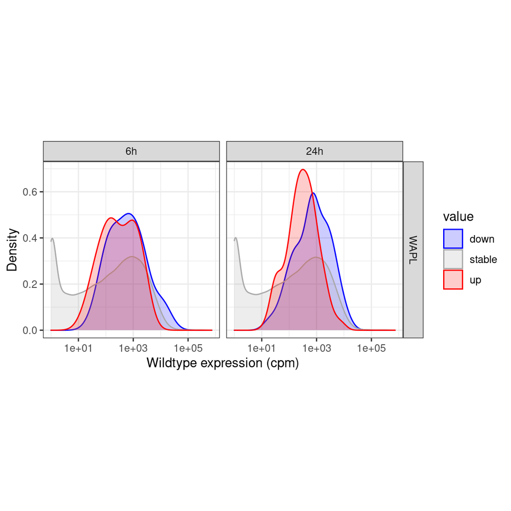

```r
plt <- tib %>%
  ggplot(aes(x = WAPL_6h_vs_WAPL_0h_baseMean+1, col = value, fill = value)) +
  geom_density(alpha = 0.2) +
  scale_x_log10() +
  facet_grid(condition ~ timepoint, scales = "free_y") +
  scale_color_manual(values = c(c("blue", "darkgrey", "red"))) +
  scale_fill_manual(values = c(c("blue", "darkgrey", "red"))) +
  xlab("Wildtype expression (cpm)") +
  ylab("Density") +
  theme_bw() +
  theme(aspect.ratio = 1)
plot(plt)
```

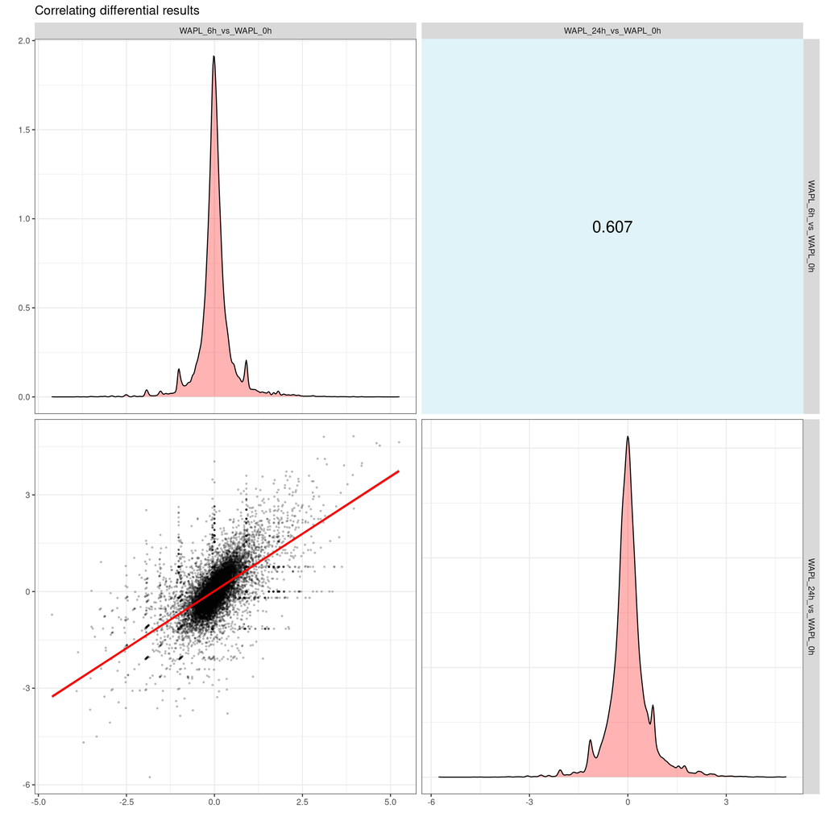

```r
# From Fede:
# ggpairs custom functions
corColor <- function(data, mapping, color = I("black"), sizeRange = c(1, 3), ...) {

  x   <- eval_data_col(data, mapping$x)
  y   <- eval_data_col(data, mapping$y)
  r   <- cor(x, y)
  rt  <- format(r, digits = 3)
  tt  <- as.character(rt)
  cex <- max(sizeRange)

  # helper function to calculate a useable size
  percent_of_range <- function(percent, range) {
    percent * diff(range) + min(range, na.rm = TRUE)
  }

  # plot correlation coefficient
  p <- ggally_text(label = tt, mapping = aes(), xP = 0.5, yP = 0.5,
                   # size = I(percent_of_range(cex * abs(r), sizeRange)),
                   size = 6,
                   color = color, ...) +
    theme(panel.grid.minor=element_blank(),
          panel.grid.major=element_blank())

  corColors <- RColorBrewer::brewer.pal(n = 7, name = "RdYlBu")[2:6]

  if (r <= boundaries[1]) {
    corCol <- corColors[1]
  } else if (r <= boundaries[2]) {
    corCol <- corColors[2]
  } else if (r < boundaries[3]) {
    corCol <- corColors[3]
  } else if (r < boundaries[4]) {
    corCol <- corColors[4]
  } else {
    corCol <- corColors[5]
  }

  p <- p +
    theme(panel.background = element_rect(fill = corCol))

  return(p)
}

customScatter <- function (data, mapping)
{
    p <- ggplot(data = data, mapping) +
      geom_point(alpha = 0.2, size = 0.5) +
      geom_smooth(method = "lm", se = T, col = "red") +
      theme_bw()

    p
}


# log2 values
tib_log2 <- as_tibble(mcols(genes_results)) %>%
  dplyr::select(contains("log2"),
                -matches("0h.*0h"),
                -contains("NQ")) %>%
  #filter(gene_idx) %>%
  rename_all(function(x) str_remove(x, "_log.*"))

# Use GGally to make correlation plots
boundaries <- seq(from = 0.1, to = 0.7, length.out = 4)
plt <- ggpairs(tib_log2 %>% drop_na(),
               upper = list(continuous = corColor),
               lower = list(continuous = customScatter),
               diag = list(continuous = function(data, mapping, ...) {
                   ggally_densityDiag(data = data, mapping = mapping, alpha = 0.3, fill = "red") +
                   theme_bw()})) +
  ggtitle("Correlating differential results") +
  xlab("") +
  ylab("")

print(plt)
```

Let’s save bed files of the significant genes.

```r
# Bed file dir
diff_dir <- file.path(output_dir, "differential_analysis")
dir.create(diff_dir, showWarnings = F)

# Get the first base of every gene
genes_start <- genes_results
mcols(genes_start) <- NULL
start(genes_start) <- end(genes_start) <- ifelse(strand(genes_start) == "+",
                                                 start(genes_start),
                                                 end(genes_start))

# Loop over comparisons
for (n in names(mcols(genes_results))) {

  if (! grepl("sign", n)) next

  # Get the results
  n_res <- mcols(genes_results)[, n]

  # Save differential genes
  export.bed(genes_start[n_res == "up"],
             file.path(diff_dir,
                       paste0(n, "_up.bed")))
  export.bed(genes_start[n_res == "down"],
             file.path(diff_dir,
                       paste0(n, "_down.bed")))

  # Save gene lists
  write_tsv(tibble(gene = genes$gene_id[n_res == "up"]), col_names = F,
            file.path(diff_dir, paste0(n, "_up_list.txt")))
  write_tsv(tibble(gene = genes$gene_id[n_res == "down"]), col_names = F,
            file.path(diff_dir, paste0(n, "_down_list.txt")))

}

write_tsv(tibble(gene = genes$gene_id), col_names = F,
          file.path(diff_dir, "genes_all_list.txt"))
```

### Conclusion

Differential nascent gene expression following WAPL depletion. Good.

I will use this later to compare with the DamID data.